# 2.1.a - Class Activity

This assignment illustrates the important of data visuals when trying to understand the distribution of data. We will use data available in the `datasauRus`. Please be sure you have installed this package (perhaps using the `install.packages()` function) before you try to proceed with the activity.

```r
library(tidyverse)
library(datasauRus)
```

# 1 Problem

**Discuss with a partner:** What is the difference in the two datasets printed below? Which of the two datasets would be considered “tidy”?

```r
datasaurus_dozen_wide
```

```
# A tibble: 142 × 26
   away_x away_y bullseye_x bullseye_y circle_x circle_y dino_x dino_y dots_x
    <dbl>  <dbl>      <dbl>      <dbl>    <dbl>    <dbl>  <dbl>  <dbl>  <dbl>
 1   32.3   61.4       51.2       83.3     56.0     79.3   55.4   97.2   51.1
 2   53.4   26.2       59.0       85.5     50.0     79.0   51.5   96.0   50.5
 3   63.9   30.8       51.9       85.8     51.3     82.4   46.2   94.5   50.2
 4   70.3   82.5       48.2       85.0     51.2     79.2   42.8   91.4   50.1
 5   34.1   45.7       41.7       84.0     44.4     78.2   40.8   88.3   50.6
 6   67.7   37.1       37.9       82.6     45.0     77.9   38.7   84.9   50.3
 7   53.3   97.5       39.5       80.8     48.6     78.8   35.6   79.9   25.6
 8   63.5   25.1       39.6       82.7     42.1     76.9   33.1   77.6   25.5
 9   68.0   81.0       34.8       80.0     41.0     76.4   29.0   74.5   25.4
10   67.4   29.7       27.6       72.8     34.6     72.7   26.2   71.4   25.6
# ℹ 132 more rows
# ℹ 17 more variables: dots_y <dbl>, h_lines_x <dbl>, h_lines_y <dbl>,
#   high_lines_x <dbl>, high_lines_y <dbl>, slant_down_x <dbl>,
#   slant_down_y <dbl>, slant_up_x <dbl>, slant_up_y <dbl>, star_x <dbl>,
#   star_y <dbl>, v_lines_x <dbl>, v_lines_y <dbl>, wide_lines_x <dbl>,
#   wide_lines_y <dbl>, x_shape_x <dbl>, x_shape_y <dbl>
```

```r
datasaurus_dozen
```

```
# A tibble: 1,846 × 3
   dataset     x     y
   <chr>   <dbl> <dbl>
 1 dino     55.4  97.2
 2 dino     51.5  96.0
 3 dino     46.2  94.5
 4 dino     42.8  91.4
 5 dino     40.8  88.3
 6 dino     38.7  84.9
 7 dino     35.6  79.9
 8 dino     33.1  77.6
 9 dino     29.0  74.5
10 dino     26.2  71.4
# ℹ 1,836 more rows
```

*The “wide” version has each of the different pairs of coordinates in separate columns. This is not tidy, since there should be only one column devoted to “x” coordinates and one column devoted to “y” coordinates. The non wide version of the data is tidy because it only has one column per coordinate and includes an additional column specifying the data type.*

# 2 Problem

Use a tidyverse chain (code separated by pipes) to determine the mean and standard deviation for the “x” and “y” variable for each unique dataset in the `datasaurus_dozen` tibble (i.e. tidyverse data.frame). This means that your dataset should have four variables:

- `mean_x`
- `mean_y`
- `sd_x`
- `sd_y`

```r
datasaurus_summary <- datasaurus_dozen |>
  group_by(dataset) |>
  summarize(
    mean_x = mean(x),
    mean_y = mean(y),
    sd_x = sd(x),
    sd_y = sd(y)
  )

datasaurus_summary
```

```
# A tibble: 13 × 5
   dataset    mean_x mean_y  sd_x  sd_y
   <chr>       <dbl>  <dbl> <dbl> <dbl>
 1 away         54.3   47.8  16.8  26.9
 2 bullseye     54.3   47.8  16.8  26.9
 3 circle       54.3   47.8  16.8  26.9
 4 dino         54.3   47.8  16.8  26.9
 5 dots         54.3   47.8  16.8  26.9
 6 h_lines      54.3   47.8  16.8  26.9
 7 high_lines   54.3   47.8  16.8  26.9
 8 slant_down   54.3   47.8  16.8  26.9
 9 slant_up     54.3   47.8  16.8  26.9
10 star         54.3   47.8  16.8  26.9
11 v_lines      54.3   47.8  16.8  26.9
12 wide_lines   54.3   47.8  16.8  26.9
13 x_shape      54.3   47.8  16.8  26.9
```

# 3 Problem

**Discuss with a partner:** What do you observe about the grouped means and standard deviations for both variables?

*They all have nearly identical means and standard deviations for each group of points*.

# 4 Problem

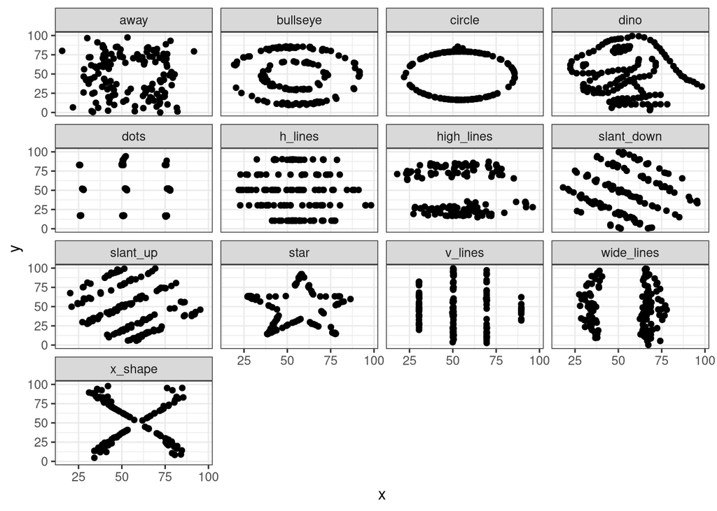

```r
ggplot(datasaurus_dozen, aes(x = x, y = y)) +
  geom_point() +
  facet_wrap(~ dataset) +
  theme_bw()
```

Note that each of the above plots follow the principle of “small multiples” which means that each plot is identical in format and differs only in the data that is represented. This is a really powerful way to compare information across groups.

# 5 Problem

**Discuss with a partner:** Describe what you see in the above plot. What do these visuals say about the representative-ness of the mean and standard deviation in describing the distribution of the data?

*The plots are all create unique visuals, including a dinosaur! This suggests that the mean and standard deviation were poor representations of the data and that the only way to truly understand these data were to visualize them.*